# Statistical Analysis

2022-09-27

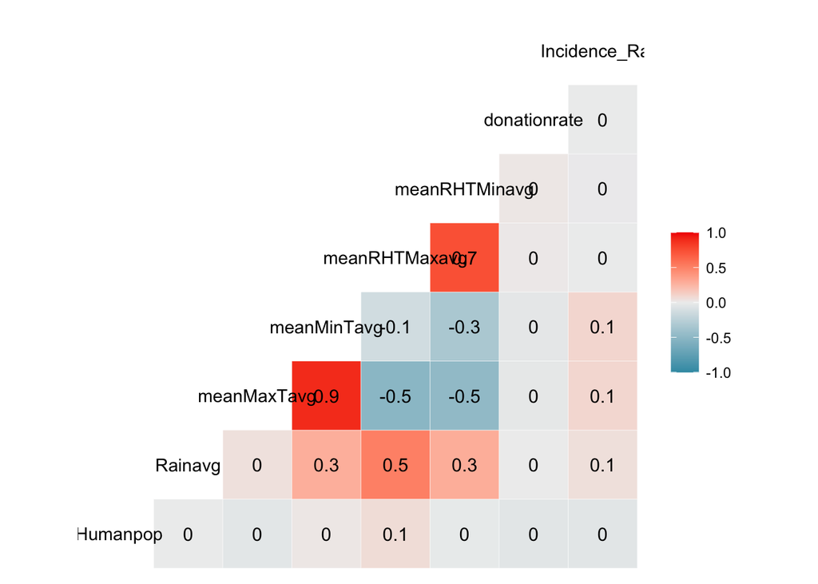

| Humanpop | -0.0448032 |
| --- | --- |
| Rainavg | 0.0526361 |
| meanMaxTavg | 0.0930843 |
| meanMinTavg | 0.0959326 |
| meanRHTMaxavg | -0.0055580 |
| meanRHTMinavg | -0.0066230 |
| donationrate | -0.0057572 |

| Population | -0.0448032 |
| --- | --- |
| Rainfall | 0.0526361 |
| Temperature | 0.0970365 |
| Humidity | -0.0064700 |
| Donation_Rate | -0.0057572 |
| Incidence_Rate | 1.0000000 |

A correlation of -1.0 indicates a perfect negative correlation, and a correlation of 1.0 indicates a perfect positive correlation. If the correlation coefficient is greater than zero, it is a positive relationship. Conversely, if the value is less than zero, it is a negative relationship.

# PCA

Summary of PCA data

|  | PC1 | PC2 | PC3 | PC4 | PC5 | PC6 |
| --- | --- | --- | --- | --- | --- | --- |
| Standard deviation | 1.502598 | 1.180189 | 1.061516 | 0.8773006 | 0.5452621 | 0.3944232 |
| Proportion of Variance | 0.376300 | 0.232140 | 0.187800 | 0.1282800 | 0.0495500 | 0.0259300 |
| Cumulative Proportion | 0.376300 | 0.608440 | 0.796240 | 0.9245200 | 0.9740700 | 1.0000000 |

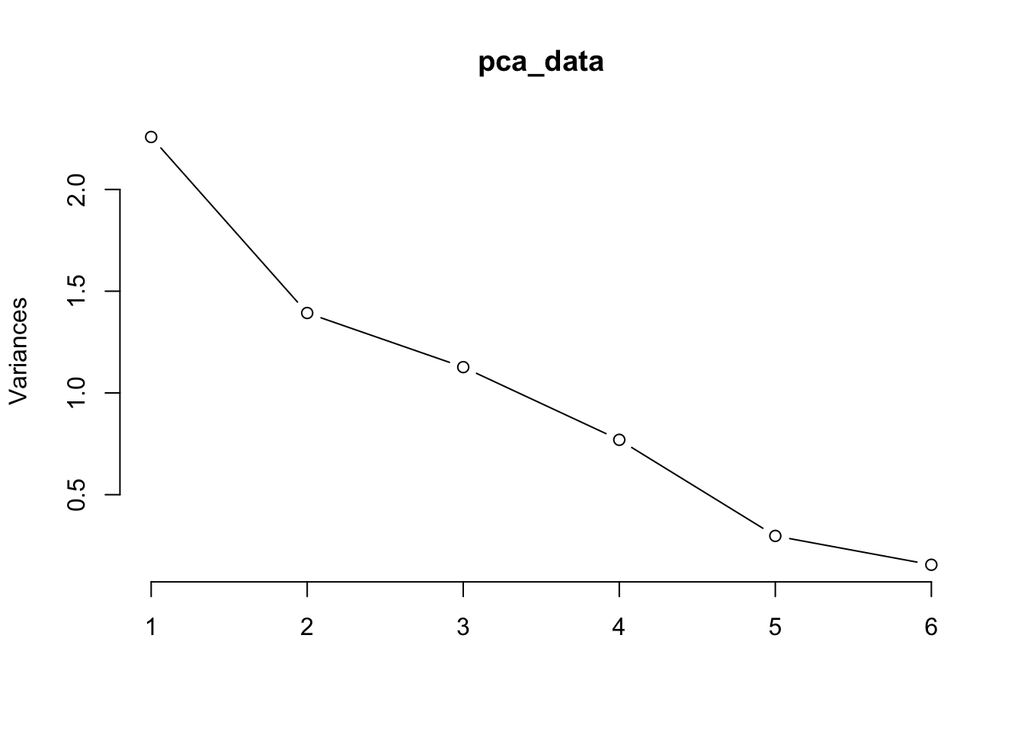

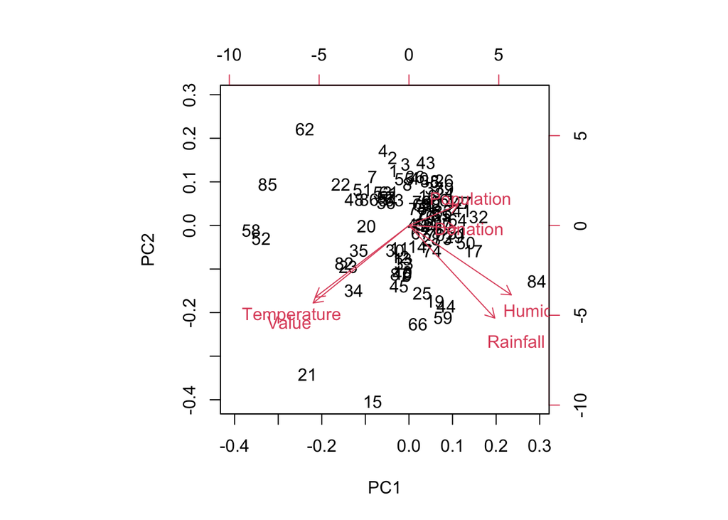

# Clusters

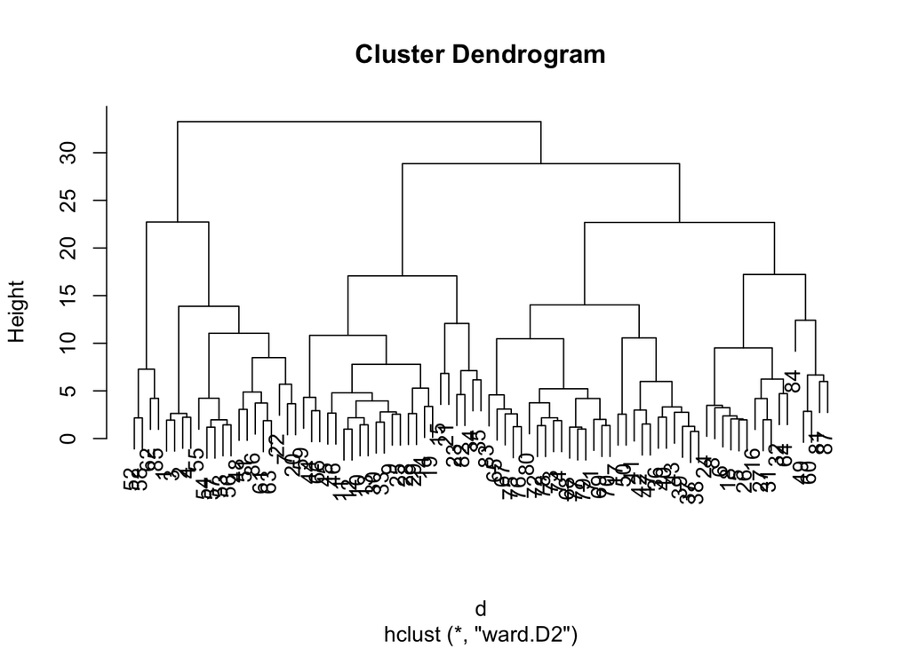

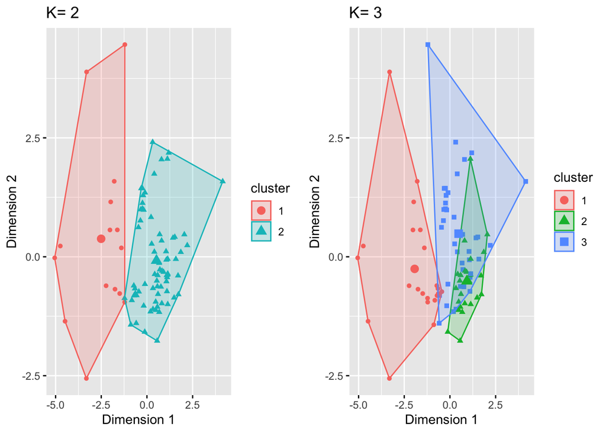

# Negative bionomial

```
## [1] "Mean of IR 0.014"
```

```
## [1] "Variance of IR 0.0589"
```

```
## [1] "Variance Ratio 4.1961"
```

# Summary stats

```
##
## Call:
## glm.nb(formula = Value ~ Donation, data = nb_data, init.theta = 0.006318631261,
##     link = log)
##
## Deviance Residuals:
##     Min       1Q   Median       3Q      Max
## -0.1135  -0.1135  -0.1135  -0.1135   5.5046
##
## Coefficients:
##              Estimate Std. Error  z value Pr(>|z|)
## (Intercept)  -4.49140    0.02532 -177.368   <2e-16 ***
## Donation    -12.30145  424.95949   -0.029    0.977
## ---
## Signif. codes:  0 '***' 0.001 '**' 0.01 '*' 0.05 '.' 0.1 ' ' 1
##
## (Dispersion parameter for Negative Binomial(0.0063) family taken to be 1)
##
##     Null deviance: 8644.1  on 386039  degrees of freedom
## Residual deviance: 8643.5  on 386038  degrees of freedom
##   (22440 observations deleted due to missingness)
## AIC: 35573
##
## Number of Fisher Scoring iterations: 1
##
##
##               Theta:  0.006319
##           Std. Err.:  0.000208
##
##  2 x log-likelihood:  -35567.149000
```

```
##
## Call:
## glm(formula = Value ~ Donation + Population, family = "poisson",
##     data = nb_data)
##
## Deviance Residuals:
##     Min       1Q   Median       3Q      Max
## -0.2629  -0.1772  -0.1483  -0.1058  21.8660
##
## Coefficients:
##               Estimate Std. Error  z value Pr(>|z|)
## (Intercept) -3.365e+00  3.082e-02 -109.176   <2e-16 ***
## Donation    -9.409e+00  5.699e+01   -0.165    0.869
## Population  -1.898e-05  5.458e-07  -34.769   <2e-16 ***
## ---
## Signif. codes:  0 '***' 0.001 '**' 0.01 '*' 0.05 '.' 0.1 ' ' 1
##
## (Dispersion parameter for poisson family taken to be 1)
##
##     Null deviance: 46407  on 386039  degrees of freedom
## Residual deviance: 44730  on 386037  degrees of freedom
##   (22440 observations deleted due to missingness)
## AIC: 50428
##
## Number of Fisher Scoring iterations: 11
```

```
##
## Call:
## glm.nb(formula = Value ~ Donation + Population, data = nb_data,
##     init.theta = 0.007856917011, link = log)
##
## Deviance Residuals:
##     Min       1Q   Median       3Q      Max
## -0.1619  -0.1311  -0.1173  -0.0924   6.5834
##
## Coefficients:
##               Estimate Std. Error z value Pr(>|z|)
## (Intercept) -3.387e+00  5.079e-02 -66.698   <2e-16 ***
## Donation    -1.439e+01  6.942e+02  -0.021    0.983
## Population  -1.861e-05  7.585e-07 -24.535   <2e-16 ***
## ---
## Signif. codes:  0 '***' 0.001 '**' 0.01 '*' 0.05 '.' 0.1 ' ' 1
##
## (Dispersion parameter for Negative Binomial(0.0079) family taken to be 1)
##
##     Null deviance: 9731.8  on 386039  degrees of freedom
## Residual deviance: 8979.5  on 386037  degrees of freedom
##   (22440 observations deleted due to missingness)
## AIC: 34867
##
## Number of Fisher Scoring iterations: 1
##
##
##               Theta:  0.007857
##           Std. Err.:  0.000260
##
##  2 x log-likelihood:  -34859.014000
```

AIC: The Akaike information criterion (AIC) is an information-theoretic measure that describes the quality of a model. A model with a low AIC is characterized by low complexity and a good fit.

Median: Since the median deviance residual is close to zero, this means that our model is not biased in one direction (i.e. the out come is neither over- nor underestimated).

Coefficients:

Dispersion Parameter: or Theta simply indicates whether a distribution is wide or narrow. The GLM function can use a dispersion parameter to model the variability.

Null deviance: A low null deviance implies that the data can be modeled well merely using the intercept. If the null deviance is low, you should consider using few features for modeling the data. if the null deviance is high, which means it makes sense to use more than a single parameter for fitting the model.

Residual deviance: A low residual deviance implies that the model you have trained is appropriate.

# Zero Inflated Count Data Regression

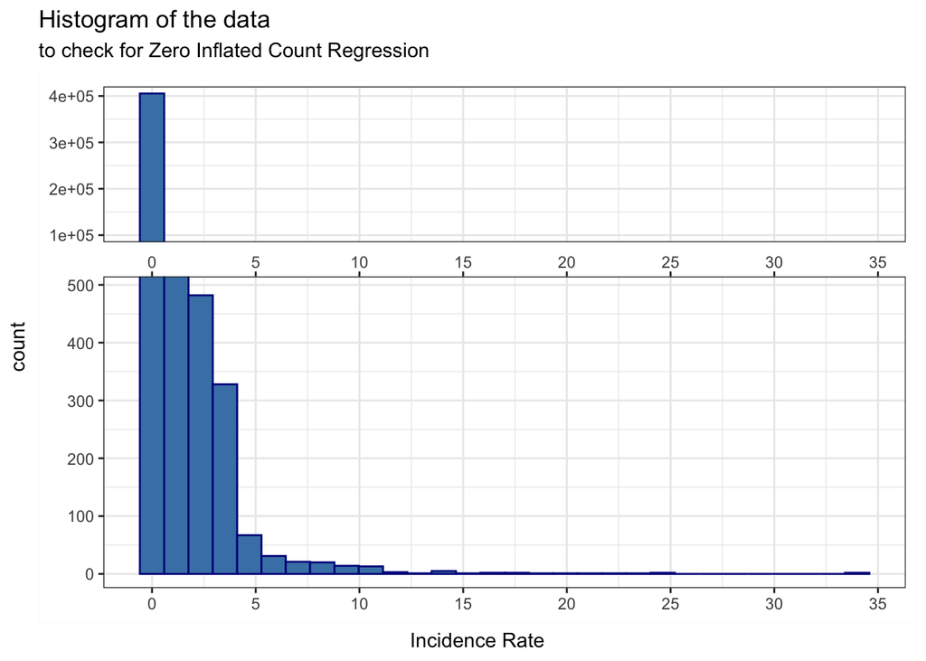

```
##
## Call:
## zeroinfl(formula = nb_data$Value ~ nb_data$Donation, data = nb_data,
##     dist = "negbin", link = "logit")
##
## Pearson residuals:
##       Min        1Q    Median        3Q       Max
##  -0.06356  -0.06356  -0.06356  -0.06356 192.81145
##
## Count model coefficients (negbin with log link):
##                  Estimate Std. Error z value Pr(>|z|)
## (Intercept)      -4.49140    0.02532 -177.37   <2e-16 ***
## nb_data$Donation -5.01542   18.55690   -0.27    0.787
## Log(theta)       -5.06425    0.03294 -153.73   <2e-16 ***
##
## Zero-inflation model coefficients (binomial with logit link):
##                  Estimate Std. Error z value Pr(>|z|)
## (Intercept)        -16.34        NaN     NaN      NaN
## nb_data$Donation     8.44    1475.56   0.006    0.995
## ---
## Signif. codes:  0 '***' 0.001 '**' 0.01 '*' 0.05 '.' 0.1 ' ' 1
##
## Theta = 0.0063
## Number of iterations in BFGS optimization: 14
## Log-likelihood: -1.778e+04 on 5 Df
```

# Conclusion stats

```
##       df      AIC
## negb   4 34867.01
## zinb   5 35577.16
## negb1  3 35573.15
## pois   3 50427.61
```

```
## [1] "Dispersion Parameter 0.0078569170113574"
```

```
## [1] "Null Deviance 9731.77335365828"
```

```
## [1] "Residual Deviance 8979.51863570784"
```

```
## [1] "Degree of Freedom 386037"
```

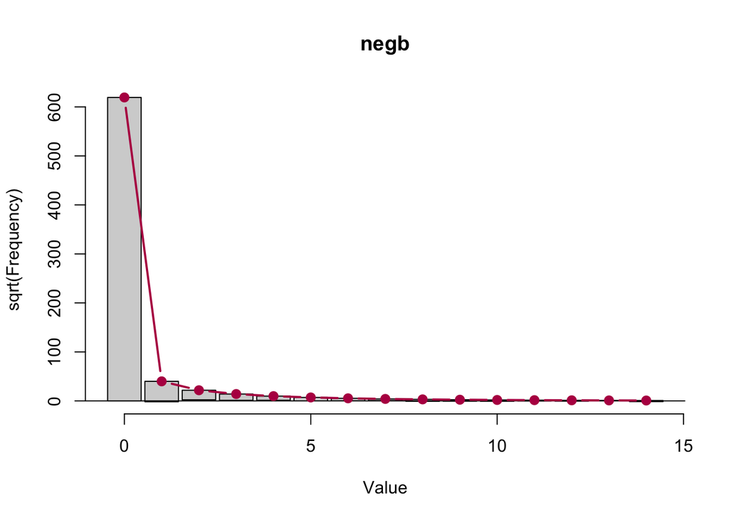

# Extras

## 3d lm for donation rate

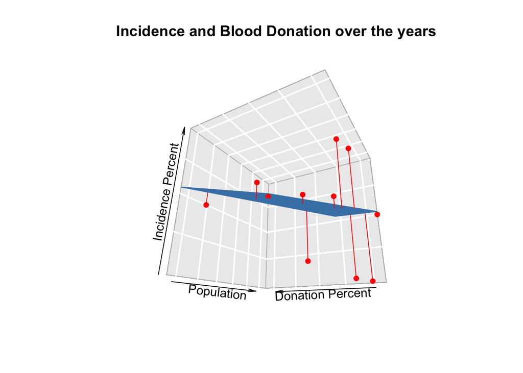

# extras

## 3d plots for weather

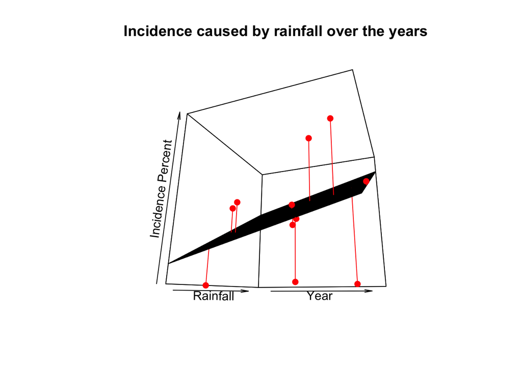

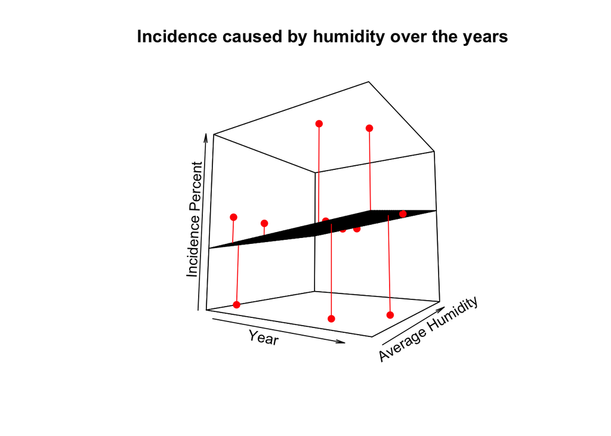

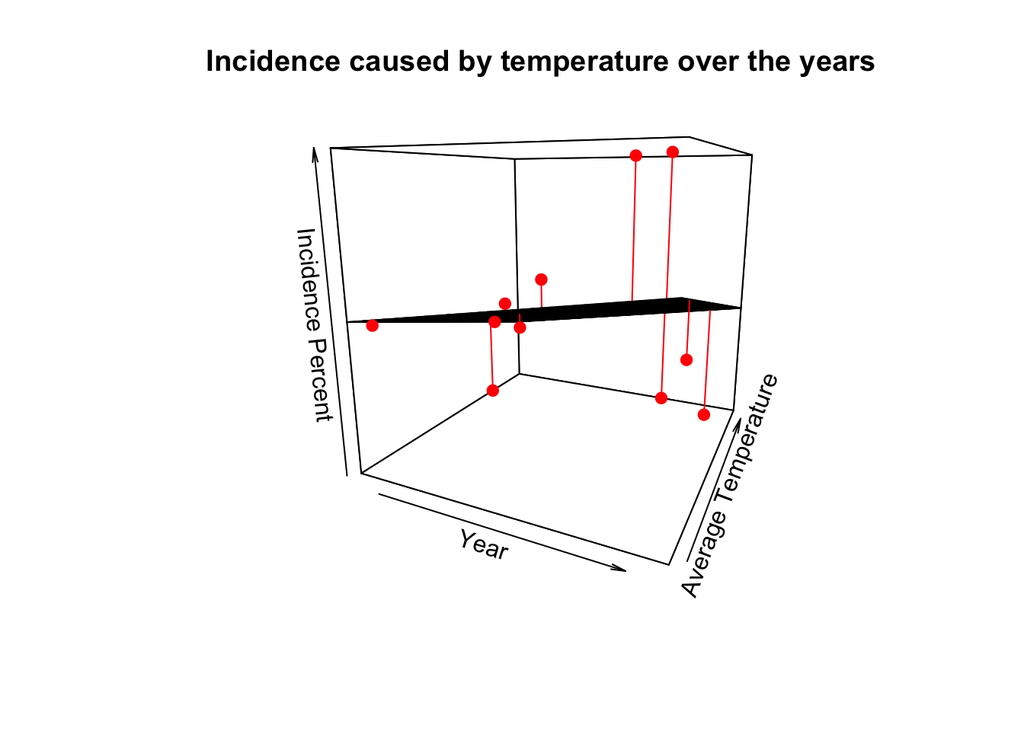